# Instagram Posts:

```python
!pip install wordcloud
```

```python
!pip install nltk
```

```python
import pandas as pd
import numpy as np
import json
import matplotlib.pyplot as plt
import seaborn as sns
import os
import string
from datetime import datetime
import glob
from wordcloud import WordCloud, STOPWORDS
import nltk
from collections import Counter
from sklearn.feature_extraction.text import CountVectorizer
nltk.download('punkt')
```

# Loading Data:

Data from Instagram (IG) posts are loaded for three companies used for the analysis: Offcorss, EPK and Polito:

```python
# Companies included in the analysis:
company_names = ['offcorss', 'epk', 'polito']
```

```python
# Function to get the text from the posts:
def get_post_text(value):
    if len(value['edges']) > 0:
        texto = value['edges'][0]['node']['text']
    else:
        texto = ''
    return texto
```

```python
# Function to get the hashtags from the text in each post:
def get_hashtags(texto):
    hashtags = []
    texto = nltk.word_tokenize(texto)
    for i, word in enumerate(texto):
        if word=='#' and i<(len(texto)-1):
            hashtags.append(texto[i+1])
    return hashtags
```

```python
# Reading json files with Instagram posts for all companies:
company_posts_df = []
for company in company_names:
    files_list = glob.glob(f'/home/jovyan/work/DS4A/Project/Instagram/{company}/*.json')

    list_of_df = []
    for file in files_list:
        if 'comment' not in file:
            temp_df = pd.read_json(file).drop(columns='instaloader')
            list_of_df.append(temp_df)
    company_posts = pd.concat(list_of_df, axis=1).transpose()
    df_info = ['display_url', 'edge_media_preview_like', 'edge_media_to_caption', 'edge_media_to_comment', 'id', 'taken_at_timestamp']
    company_posts = company_posts.loc[:, df_info]
    company_posts['posts_company'] = company
    company_posts_df.append(company_posts)

ig_posts = pd.concat(company_posts_df)
ig_posts = ig_posts.rename(columns={'display_url':'post_url',
                          'edge_media_preview_like':'post_likes_count',
                         'edge_media_to_caption':'post_text',
                         'edge_media_to_comment':'post_comments_count',
                         'id':'post_id',
                         'taken_at_timestamp':'post_date'})
ig_posts = ig_posts.reset_index(drop=True)
ig_posts = ig_posts.dropna(axis=0)

ig_posts['post_likes_count'] = ig_posts['post_likes_count'].apply(lambda x: x['count'])
ig_posts['post_comments_count'] = ig_posts['post_comments_count'].apply(lambda x: x['count'])
ig_posts['post_date'] = ig_posts['post_date'].apply(lambda x: datetime.fromtimestamp(x))

ig_posts['post_text'] = ig_posts['post_text'].apply(get_post_text)
ig_posts['post_hashtags'] = ig_posts['post_text'].apply(get_hashtags)
ig_posts['post_text'] = ig_posts['post_text'].apply(lambda x: x.split(' #')[0])

ig_posts.head()
```

[output not shown]

```python
ig_posts.tail(50)
```

|  | post_url | post_likes_count | post_text | post_comments_count | post_id | post_date | posts_company | post_hashtags |
| --- | --- | --- | --- | --- | --- | --- | --- | --- |
| 2575 | https://instagram.fbga1-4.fna.fbcdn.net/v/t51.... | 69 | Cuello de protección, camiseta manga larga en ... | 0 | 2380220675580469495 | 2020-08-20 23:00:37 | polito | [politokids, politoesdiversiónsinlímites, poli... |
| 2576 | https://instagram.fbga1-4.fna.fbcdn.net/v/t51.... | 102 | 🌟🍃 Tapabocas para toda la familia, muchos colo... | 0 | 2380643472523118861 | 2020-08-21 13:00:38 | polito | [politokids, politoesdiversiónsinlímites, poli... |
| 2577 | https://instagram.fbga1-4.fna.fbcdn.net/v/t51.... | 112 | ¿Qué te inspira a ser más feliz, más sonriente... | 0 | 2380809552540362504 | 2020-08-21 18:30:37 | polito | [politokids, politoesdiversiónsinlímites, prot... |
| 2578 | https://instagram.fbga1-4.fna.fbcdn.net/v/t51.... | 123 | Muchos diseños disponibles ya en un infaltable... | 2 | 2381443735224305188 | 2020-08-22 15:30:37 | polito | [politokids, politoesdiversiónsinlímites, poli... |
| 2579 | https://instagram.fbga1-4.fna.fbcdn.net/v/t51.... | 97 | ¡¡SORPRESA!!⚡⚡⚡.\n.\nAhora en Polito encontrar... | 2 | 2381719154119828566 | 2020-08-23 00:37:49 | polito | [polito, politokids, arte, artepolito, artepar... |
| 2580 | https://instagram.fbga1-4.fna.fbcdn.net/v/t51.... | 84 | 🔆 🎨 ¡¡¡NUEVOS KITS CREATIVOS!!! 🔆 🎨.\n.\nPensa... | 1 | 2382153394631736060 | 2020-08-23 15:00:35 | polito | [politoescolombia, politoesdiversiónsinlímites... |
| 2581 | https://instagram.fbga1-4.fna.fbcdn.net/v/t51.... | 152 | NUEVOS KITS CREATIVOS 🎨.\n.\nDesarrollados par... | 11 | 2383581198334864105 | 2020-08-25 14:17:22 | polito | [polito, Politokids, creatividadpolito, polito... |
| 2582 | https://instagram.fbga1-4.fna.fbcdn.net/v/t51.... | 226 | 🎨⭐KIT PINTA TU CAMISETA PARA NIÑA.\nUn Kit sup... | 8 | 2383773642557179517 | 2020-08-25 20:39:44 | polito | [Politokids, kitcreativo, actividadesparaniños... |
| 2583 | https://instagram.fbga1-4.fna.fbcdn.net/v/t51.... | 129 | Disfrutamos cada parte del proceso, ¿te animas... | 18 | 2384303286246320406 | 2020-08-26 14:12:15 | polito | [Politokids, kitcreativo, actividadesparaniños... |
| 2584 | https://instagram.fbga1-4.fna.fbcdn.net/v/t51.... | 256 | Un resultado hermoso, lleno de color y alegría... | 27 | 2384576548139016716 | 2020-08-26 23:14:57 | polito | [Politokids, kitcreativo, actividadesparaniños... |
| 2585 | https://instagram.fbga1-4.fna.fbcdn.net/v/t51.... | 161 | 🎨⭐Tu decides como pintar y crear tu propia cam... | 6 | 2385113387014846791 | 2020-08-27 17:01:34 | polito | [Politokids, kitcreativo, actividadesparaniños... |
| 2586 | https://instagram.fbga1-4.fna.fbcdn.net/v/t51.... | 79 | Colores, formas y texturas en los nuevos 🎨✨ KI... | 4 | 2385248234449722042 | 2020-08-27 21:29:52 | polito | [Politokids, kitcreativo, actividadesparaniños... |
| 2587 | https://instagram.fbga1-4.fna.fbcdn.net/v/t51.... | 141 | KIT PINTA TU CAMISETA PARA NIÑO:.\n.\n🔆🎨Un Kit... | 6 | 2385339499031822903 | 2020-08-28 00:30:48 | polito | [Politokids, kitcreativo, actividadesparaniños... |
| 2588 | https://instagram.fbga1-4.fna.fbcdn.net/v/t51.... | 164 | KIT TIE DYE PARA NIÑA✨:.\n.\nUn kit creativo c... | 6 | 2385717065118964268 | 2020-08-28 13:00:58 | polito | [Politokids, kitcreativo, actividadesparaniños... |
| 2589 | https://instagram.fbga1-4.fna.fbcdn.net/v/t51.... | 147 | Así de fácil y divertido es hacer tu camiseta ... | 12 | 2385867946531723853 | 2020-08-28 18:01:10 | polito | [Politokids, kitcreativo, actividadesparaniños... |
| 2590 | https://instagram.fbga1-4.fna.fbcdn.net/v/t51.... | 168 | ✨🌀 Para las niñas todo el estilo y diversión s... | 8 | 2386003792706471689 | 2020-08-28 22:30:38 | polito | [Politokids, kitcreativo, actividadesparaniños... |
| 2591 | https://instagram.fbga1-4.fna.fbcdn.net/v/t51.... | 173 | ✨🌀Tie dye, una técnica para darle color y dive... | 5 | 2386488984365783566 | 2020-08-29 14:34:38 | polito | [Politokids, kitcreativo, actividadesparaniños... |
| 2592 | https://instagram.fbga1-4.fna.fbcdn.net/v/t51.... | 58 | Así de fácil y divertido es hacer tu camiseta ... | 2 | 2386637961547554785 | 2020-08-29 19:31:02 | polito | [Politokids, kitcreativo, actividadesparaniños... |
| 2593 | https://instagram.fbga1-4.fna.fbcdn.net/v/t51.... | 115 | ✨ 🌀 ¡Transforma tu camiseta y llénala de color... | 4 | 2386758886721018868 | 2020-08-29 23:30:52 | polito | [Politokids, kitcreativo, actividadesparaniños... |
| 2594 | https://instagram.fbga1-4.fna.fbcdn.net/v/t51.... | 45 | ¡Buenas noticias! 💛💛💛Ahora llegamos más rapido... | 0 | 2388740606651351321 | 2020-09-01 17:08:12 | polito | [Politokids, politochat, mascercadeti, domicil... |
| 2595 | https://instagram.fbga1-4.fna.fbcdn.net/v/t51.... | 67 | 💛 💛 💛 Nada más facil que hablar con una person... | 3 | 2388887648421818802 | 2020-09-01 22:00:21 | polito | [Politokids, politochat, mascercadeti, domicil... |
| 2596 | https://instagram.fbga1-4.fna.fbcdn.net/v/t51.... | 48 | Comunícate con POLIⓣⓞCHAT al 3053473055 🔆LINK ... | 0 | 2388963074674601207 | 2020-09-02 00:30:12 | polito | [Politokids, politochat, mascercadeti, domicil... |
| 2597 | https://instagram.fbga1-4.fna.fbcdn.net/v/t51.... | 78 | Así de fácil es ahora realizar tus pedidos, PO... | 8 | 2389325573118837947 | 2020-09-02 12:30:25 | polito | [Politokids, politochat, mascercadeti, domicil... |
| 2598 | https://instagram.fbga1-4.fna.fbcdn.net/v/t51.... | 46 | POLIⓣⓞCHAT✨✨✨ es la nueva forma de estar más c... | 0 | 2389506662277998637 | 2020-09-02 18:30:13 | polito | [Politokids, politochat, mascercadeti, domicil... |
| 2599 | https://instagram.fbga1-4.fna.fbcdn.net/v/t51.... | 58 | POLIⓣⓞCHAT es la nueva plataforma de servicio ... | 1 | 2389718065291058706 | 2020-09-03 01:30:14 | polito | [Politokids, politochat, mascercadeti, domicil... |
| 2600 | https://instagram.fbga1-4.fna.fbcdn.net/v/t51.... | 273 | 🌞 🌞 🌞 Días de sol llenos de comodidad y mucho ... | 1 | 2391737950082721978 | 2020-09-05 20:23:23 | polito | [Politokids, ropainfantil, rollerland, juegosd... |
| 2601 | https://instagram.fbga1-4.fna.fbcdn.net/v/t51.... | 244 | Mano arriba si eres de este team👗💛 , nos encan... | 15 | 2391813201777032458 | 2020-09-05 22:52:54 | polito | [Politokids, ropainfantil, rollerland, juegosd... |
| 2602 | https://instagram.fbga1-4.fna.fbcdn.net/v/t51.... | 258 | 🎨Colores vibrantes, telas suaves en un vestido... | 6 | 2392337095219627724 | 2020-09-06 16:13:47 | polito | [Politokids, ropainfantil, rollerland, juegosd... |
| 2603 | https://instagram.fbga1-4.fna.fbcdn.net/v/t51.... | 343 | ¿Qué tal la belleza y ternura de este vestido?... | 19 | 2392549839662503741 | 2020-09-06 23:16:28 | polito | [Politokids, ropainfantil, rollerland, juegosd... |
| 2604 | https://instagram.fbga1-4.fna.fbcdn.net/v/t51.... | 142 | ¡Girl power! 💛💗💚 Un buzo para días lluviosos c... | 1 | 2392602173344277519 | 2020-09-07 01:00:26 | polito | [Politokids, ropainfantil, rollerland, juegosd... |
| 2605 | https://instagram.fbga1-4.fna.fbcdn.net/v/t51.... | 243 | 💛 💛 💛 ¿En que ocasión utilizarías este look?.\... | 12 | 2393054985546952874 | 2020-09-07 16:00:06 | polito | [Politokids, ropainfantil, rollerland, juegosd... |
| 2606 | https://instagram.fbga1-4.fna.fbcdn.net/v/t51.... | 143 | 💛 🌟 Vestidos, camisetas, camisas, jeans, todo ... | 2 | 2393195913867805169 | 2020-09-07 20:40:06 | polito | [Politokids, ropainfantil, rollerland, juegosd... |
| 2607 | https://instagram.fbga1-4.fna.fbcdn.net/v/t51.... | 144 | 🍃🔆Sonrisas y movimiento, a eso le llamamos vid... | 1 | 2393848364246392720 | 2020-09-08 18:16:24 | polito | [Politokids, ropainfantil, rollerland, juegosd... |
| 2608 | https://instagram.fbga1-4.fna.fbcdn.net/v/t51.... | 210 | 💛🎨 Un conjunto colorido y súper cómodo para qu... | 2 | 2394006348510655507 | 2020-09-08 23:30:17 | polito | [Politokids, ropainfantil, rollerland, juegosd... |
| 2609 | https://instagram.fbga1-4.fna.fbcdn.net/v/t51.... | 158 | 💓🔆¡Vamos a saltar y a disfrutar cada instante ... | 0 | 2394431081291735724 | 2020-09-09 13:34:09 | polito | [Politokids, ropainfantil, rollerland, juegosd... |
| 2610 | https://instagram.fbga1-4.fna.fbcdn.net/v/t51.... | 173 | Muchas opciones que puedes encontrar en la más... | 5 | 2395889282003997604 | 2020-09-11 13:51:20 | polito | [Politokids, ropainfantil, rollerland, juegosd... |
| 2611 | https://instagram.fbga1-4.fna.fbcdn.net/v/t51.... | 98 | 🔆Jumpsuit para niña, una prenda ideal para div... | 0 | 2396167123690644680 | 2020-09-11 23:03:22 | polito | [Politokids, ropainfantil, rollerland, juegosd... |
| 2612 | https://instagram.fbga1-4.fna.fbcdn.net/v/t51.... | 124 | 🍃 Conjunto para niño desde talla 24M hasta 5T,... | 4 | 2396210901293347923 | 2020-09-12 00:30:20 | polito | [Politokids, ropainfantil, rollerland, juegosd... |
| 2613 | https://instagram.fbga1-4.fna.fbcdn.net/v/t51.... | 114 | 📸🔆Vamos a capturar los mejores momentos de la ... | 1 | 2396595986602343890 | 2020-09-12 13:15:26 | polito | [Politokids, ropainfantil, rollerland, juegosd... |
| 2614 | https://instagram.fbga1-4.fna.fbcdn.net/v/t51.... | 147 | 🔆 🔆 🔆 Disfruta este look en la puerta de tu ca... | 4 | 2396663884867169698 | 2020-09-12 15:30:20 | polito | [Politokids, ropainfantil, rollerland, juegosd... |
| 2615 | https://instagram.fbga1-4.fna.fbcdn.net/v/t51.... | 129 | 🔆💛Las sonrisas de nuestros niños son regalos d... | 0 | 2397342323715088238 | 2020-09-13 13:58:16 | polito | [Politokids, ropainfantil, rollerland, juegosd... |
| 2616 | https://instagram.fbga1-4.fna.fbcdn.net/v/t51.... | 208 | 🔆💛🔆Para los más pequeños prendas frescas, cómo... | 0 | 2397518035709532666 | 2020-09-13 19:47:23 | polito | [Politokids, ropainfantil, rollerland, juegosd... |
| 2617 | https://instagram.fbga1-4.fna.fbcdn.net/v/t51.... | 128 | 💛💛💛Pronto llegará el momento de compartir con ... | 5 | 2397671667578852547 | 2020-09-14 00:52:37 | polito | [Politokids, ropainfantil, rollerland, juegosd... |
| 2618 | https://instagram.fbga1-4.fna.fbcdn.net/v/t51.... | 111 | Les compartimos este video disfrutando de los ... | 3 | 2401196580054935509 | 2020-09-18 21:36:14 | polito | [] |
| 2619 | https://instagram.fbga1-4.fna.fbcdn.net/v/t51.... | 110 | 🍃💛¡Felicidad! es la palabra que ahora sentimos... | 8 | 2404053087163439470 | 2020-09-22 20:11:22 | polito | [politokids, politoesdiversionsinlimites, prot... |
| 2620 | https://instagram.fbga1-4.fna.fbcdn.net/v/t51.... | 48 | 💫 Ahora que podemos regresar a esos espacios q... | 0 | 2404122912274729636 | 2020-09-22 22:30:06 | polito | [politokids, politoesdiversionsinlimites, prot... |
| 2621 | https://instagram.fbga1-4.fna.fbcdn.net/v/t51.... | 90 | 💛🔆Las miradas ahora hablan, tienen voz, sonris... | 2 | 2404215023385659250 | 2020-09-23 01:33:06 | polito | [politokids, Polito, ropainfantil, modacolombi... |
| 2622 | https://instagram.fbga1-4.fna.fbcdn.net/v/t51.... | 301 | Tapabocas para toda la familia de alta protecc... | 11 | 2404696945357653802 | 2020-09-23 17:30:36 | polito | [politokids, Polito, ropainfantil, modacolombi... |
| 2623 | https://instagram.fbga1-4.fna.fbcdn.net/v/t51.... | 32 | 💛💛💛¡Nos encanta acompañarte en cada momento!.\... | 0 | 2404820407364255802 | 2020-09-23 21:36:07 | polito | [PolitoTeProtege, politoescolombia, politoesdi... |
| 2624 | https://instagram.fbga1-4.fna.fbcdn.net/v/t51.... | 88 | Línea de cuidado personal 💦🍃.\n.\n✨ Un complem... | 1 | 2405421489756271465 | 2020-09-24 17:30:08 | polito | [Polito, politokids, politoesdiversionsinlimit... |

The Instagram posts from these three competitors are loaded into "ig_posts" dataframe which has this information:

**Dataset: "ig_posts":**

- **post_comments_count:** Number of comments per post.
- **post_date:** Date when the post was created.
- **post_hashtags:** List of Hashtags included in each post.
- **post_id:** ID of the post. Unique identifier.
- **post_likes_count:** Number of likes per post.
- **post_text:** Text in the post.
- **post_url:** URL of the post.
- **posts_company:** Company.

There are 2623 IG posts:

```python
# Size of "ig_posts":
ig_posts.shape
```

```
(2623, 8)
```

All posts have at least 26 likes, while there are some of them where no comments are found:

```python
# Description of numeric columns in ig_posts:
ig_posts.describe()
```

|  | post_likes_count | post_comments_count |
| --- | --- | --- |
| count | 2623.000000 | 2623.000000 |
| mean | 475.469310 | 10.847884 |
| std | 534.371129 | 35.578934 |
| min | 26.000000 | 0.000000 |
| 25% | 171.000000 | 1.000000 |
| 50% | 326.000000 | 4.000000 |
| 75% | 580.000000 | 10.000000 |
| max | 11044.000000 | 724.000000 |

There are 561 posts whit no comments on it. In other words, 21.4% of the posts have no comments:

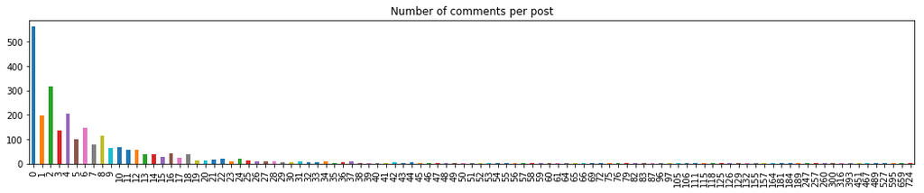

```python
ig_posts['post_comments_count'].value_counts().sort_index().plot(kind='bar', figsize=(18,3))
plt.title('Number of comments per post')
plt.show()
```

Most of the posts have less than 500 likes:

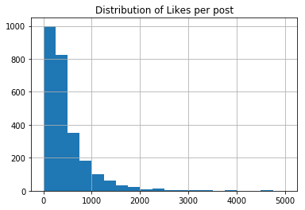

```python
ig_posts['post_likes_count'].hist(range=(0,5000), bins=20)
plt.title('Distribution of Likes per post')
plt.show()
```

```python
# Null values in "ig_posts":
ig_posts.isnull().sum()
```

```
post_url               0
post_likes_count       0
post_text              0
post_comments_count    0
post_id                0
post_date              0
posts_company          0
post_hashtags          0
dtype: int64
```

The number of posts per month shows that Offcorrs has relatively constant number of posts per month. EPK and Polito, on the other hand, have more posts in the middle of the year (May to September), though Polito increases the number of posts towards the end of the year:

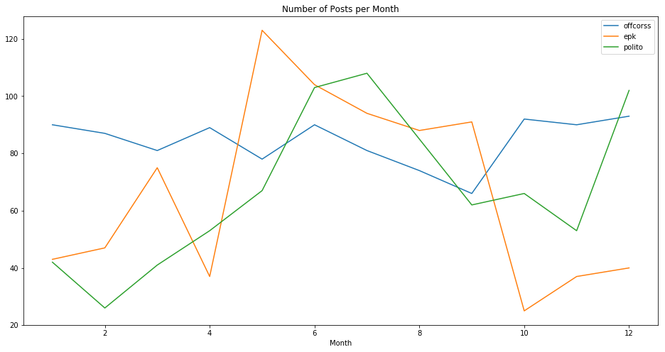

```python
# Plotting the number of posts per month per company:
fig = plt.figure(figsize=(16,8))

for i, company in enumerate(company_names):
    plot = pd.DataFrame(ig_posts.groupby(['posts_company', ig_posts['post_date'].dt.month])['post_id'].count())
    plot = plot.loc[company]
#     print(plot.index)
    sns.lineplot(x=plot.index, y=plot.post_id, label=company_names[i])

plt.title('Number of Posts per Month')
plt.ylabel('')
plt.xlabel('Month')
plt.show()
```

This plot shows that, on average, EPK has more likes count per post than Offcorss and Polito. Polito is the company with the lowest number of likes count per post:

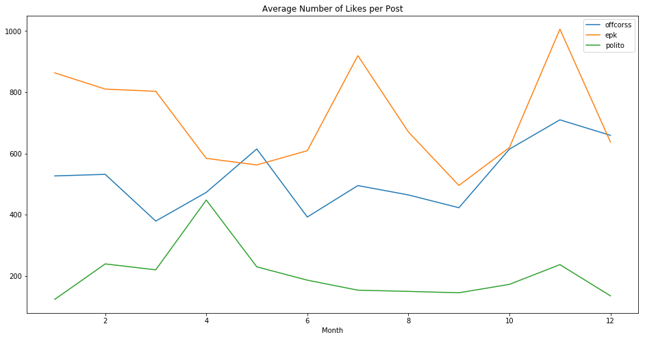

```python
# Plotting the average number of likes per post and month for each company:
fig = plt.figure(figsize=(16,8))

for i, company in enumerate(company_names):
    plot = pd.DataFrame(ig_posts.groupby(['posts_company', ig_posts['post_date'].dt.month])['post_likes_count'].mean())
    plot = plot.loc[company]
#     print(plot.index)
    sns.lineplot(x=plot.index, y=plot.post_likes_count, label=company_names[i])

plt.title('Average Number of Likes per Post')
# plt.ylim(0,1200)
plt.ylabel('')
plt.xlabel('Month')
plt.show()
```

All companies have similar number of comments per post on average, though Polito has a significantly higher number of comments in the posts from April (Additional data analysis is required to understand this. It might be related to some bad comments):

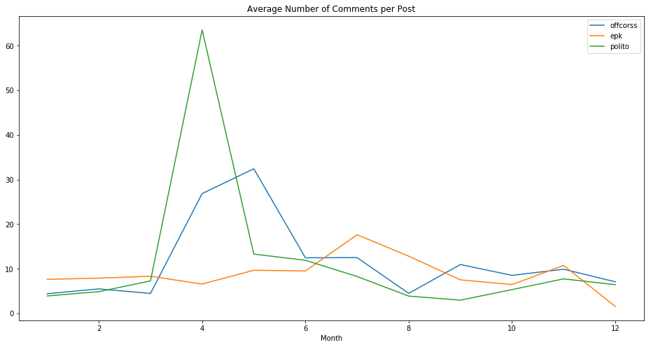

```python
# Plotting the average number of comments per post and month for each company:
fig = plt.figure(figsize=(16,8))

for i, company in enumerate(company_names):
    plot = pd.DataFrame(ig_posts.groupby(['posts_company', ig_posts['post_date'].dt.month])['post_comments_count'].mean())
    plot = plot.loc[company]
#     print(plot.index)
    sns.lineplot(x=plot.index, y=plot.post_comments_count, label=company_names[i])

plt.title('Average Number of Comments per Post')
# plt.ylim(0,1200)
plt.ylabel('')
plt.xlabel('Month')
plt.show()
```

# Non-Stopping Words:

Stopping words were removed from the text of the posts, so the most common words used in the posts can be analyzed for each company:

```python
def remove_stopping_words(value):
    non_stopping_words = []
    for x in value:
        if x not in stopwords.words(['spanish', 'english']) and x.isalpha():
            non_stopping_words.append(x)
    return non_stopping_words
```

```python
import nltk
from nltk.corpus import stopwords
```

```python
nltk.download('punkt')
nltk.download('stopwords')
```

```python
epk = ig_posts.loc[ig_posts['posts_company']=='epk', :]
epk['post_text_nsw'] = epk['post_text'].apply(lambda x: x.lower())
epk['post_text_nsw'] = epk['post_text_nsw'].apply(lambda x: nltk.word_tokenize(x))
epk['post_text_nsw'] = epk['post_text_nsw'].apply(remove_stopping_words)
epk['post_text_nsw'] = epk['post_text_nsw'].apply(lambda x: ' '.join(x))
```

```python
offcorss = ig_posts.loc[ig_posts['posts_company']=='offcorss', :]
offcorss['post_text_nsw'] = offcorss['post_text'].apply(lambda x: x.lower())
offcorss['post_text_nsw'] = offcorss['post_text_nsw'].apply(lambda x: nltk.word_tokenize(x))
offcorss['post_text_nsw'] = offcorss['post_text_nsw'].apply(remove_stopping_words)
offcorss['post_text_nsw'] = offcorss['post_text_nsw'].apply(lambda x: ' '.join(x))
```

```python
polito = ig_posts.loc[ig_posts['posts_company']=='polito', :]
polito['post_text_nsw'] = polito['post_text'].apply(lambda x: x.lower())
polito['post_text_nsw'] = polito['post_text_nsw'].apply(lambda x: nltk.word_tokenize(x))
polito['post_text_nsw'] = polito['post_text_nsw'].apply(remove_stopping_words)
polito['post_text_nsw'] = polito['post_text_nsw'].apply(lambda x: ' '.join(x))
```

Wordcloud from the text in the posts from EPK (with non-stopping words):

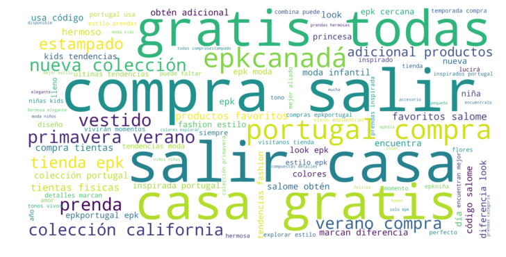

```python
# Wordcloud from the text in the posts for EPK:

word_cloud_text = ''.join(epk.post_text_nsw)
wordcloud = WordCloud(max_font_size=100, max_words=100, background_color="white",\
#                           stopwords=stopwords.words(['spanish', 'english']),\
                      scale = 10,width=800, height=400).generate(word_cloud_text)
plt.figure(figsize=(12,7))
plt.imshow(wordcloud, interpolation="bilinear")
plt.axis("off")
plt.show()
```

It can be seen that the posts from EPK have interesting comments like "salir casa", "gratis", "compra", etc, which exhibit the interest from this company to facilitate the buying and delivery process for their clients.

Wordcloud from the text in the posts from OFFCORSS (with non-stopping words):

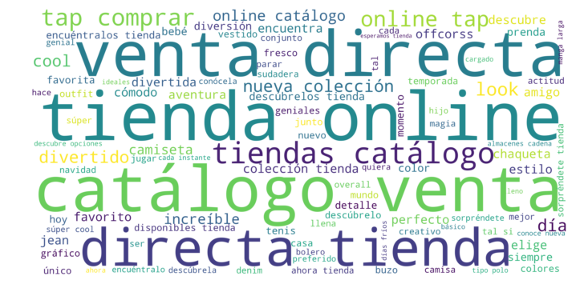

```python
# Wordcloud from the text in the posts for OFFCORSS:

word_cloud_text = ''.join(offcorss.post_text_nsw)
wordcloud = WordCloud(max_font_size=100, max_words=100, background_color="white",\
#                       stopwords=stopwords.words(['spanish', 'english']),\
                          scale = 10,width=800, height=400).generate(word_cloud_text)
plt.figure(figsize=(12,7))
plt.imshow(wordcloud, interpolation="bilinear")
plt.axis("off")
plt.show()
```

Wordcloud from the text in the posts from POLITO (with non-stopping words):

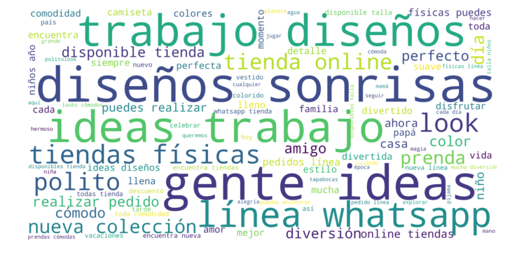

```python
# Wordcloud from the text in the posts for POLITO:

word_cloud_text = ''.join(polito.post_text_nsw)
wordcloud = WordCloud(max_font_size=100, max_words=100, background_color="white",\
#                       stopwords=stopwords.words(['spanish', 'english']),\
                          scale = 10,width=800, height=400).generate(word_cloud_text)
plt.figure(figsize=(12,7))
plt.imshow(wordcloud, interpolation="bilinear")
plt.axis("off")
plt.show()
```

Offcorss uses more comments like "venta directa", "catalogo", "tienda online", "tiendas", etc, which shows more the kind of stores that they use for their sales.

# Hashtags Analysis:

Below we can find the top10 hashtags that are used in the posts by each company:

```python
# Defining function to get and plot the top10 hashtags used in the posts:
def get_top10_hashtags(company, hashtag_column, company_column):
    hashtags_column = company[hashtag_column]
    hashtags_column = hashtags_column.apply(lambda x: ' '.join(x))

    vec = CountVectorizer()
    X = vec.fit_transform(hashtags_column)
    hashtags = pd.DataFrame(X.toarray(), columns=vec.get_feature_names())

    dic = {}
    for word in list(hashtags.columns):
        dic[word] = hashtags[word].sum()

    df = pd.DataFrame.from_dict(dic, orient='index').rename(columns={0:'Hashtag'})
    plot = df.sort_values(by='Hashtag', ascending=True).tail(10).plot(kind='barh', label='')
    plt.title(f"Top 10 Hashtags from {str.upper(company[company_column].unique()[0])}")
    plt.show()

    return plot
```

Top10 hashtags from EPK:

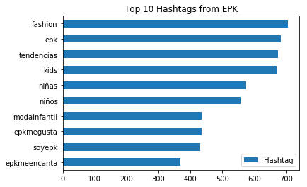

```python
get_top10_hashtags(epk, 'post_hashtags', 'posts_company')
```

Top10 hashtags from OFFCORSS:

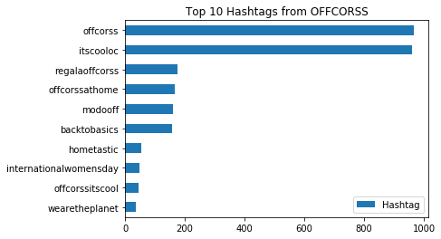

```python
get_top10_hashtags(offcorss, 'post_hashtags', 'posts_company')
```

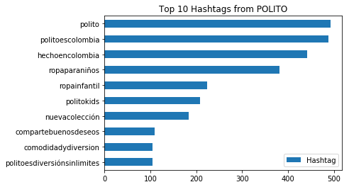

```python
get_top10_hashtags(polito, 'post_hashtags', 'posts_company')
```

Based on above analysis, it can be seen that the hashtags used by OFFCORSS are mainly two: "offcorss" and "itscooloc", while EPK uses more hashtags more often: "fashion", "epk", "tendencias", "kids", "ninas", "ninos", among others.

```python
ig_posts.to_csv('instagram_posts_W.csv')
```

# Instagram Responses:

Reading and preparing data from the responses to Instagram posts for each company:

```python
ig_responses = pd.read_csv(r'instagram_responses.csv')
ig_responses['time'] = pd.to_datetime(ig_responses['time'])
ig_responses['hashtags'] = ig_responses['text'].apply(get_hashtags)
ig_responses['text_nsw'] = ig_responses['text'].apply(lambda x: x.lower())
ig_responses['text_nsw'] = ig_responses['text_nsw'].apply(lambda x: nltk.word_tokenize(x))
ig_responses['text_nsw'] = ig_responses['text_nsw'].apply(remove_stopping_words)
ig_responses['text_nsw'] = ig_responses['text_nsw'].apply(lambda x: ' '.join(x))
ig_responses['text_length'] = ig_responses['text'].apply(lambda x: x.lower())
ig_responses['text_length'] = ig_responses['text'].apply(lambda x: len(nltk.word_tokenize(x)))
ig_responses.head()
```

|  | rootPost_id | parentPost_id | reponsePost_id | brand_username | text | time | likes | username | hashtags | text_nsw | text_length |
| --- | --- | --- | --- | --- | --- | --- | --- | --- | --- | --- | --- |
| 0 | 1947257691818809835 | 1.947258e+18 | 1.794235e+16 | offcorss | Así es un día para disfrutar sana mente y con... | 2019-01-01 16:42:54 | 1 | rosaliafaneite | [] | así día disfrutar sana mente exito | 11 |
| 1 | 1947952244502703605 | 1.947952e+18 | 1.801764e+16 | offcorss | Buenos días que precio tienen? | 2019-01-02 16:45:57 | 1 | aleja.vasquez911 | [] | buenos días precio | 6 |
| 2 | 1948073194162672935 | 1.948073e+18 | 1.791861e+16 | offcorss | 🎊 | 2019-01-02 18:48:08 | 1 | pactrii188 | [] |  | 1 |
| 3 | 1948284380053077836 | 1.948284e+18 | 1.798609e+16 | offcorss | Hermosa mi sheshe | 2019-01-03 03:33:23 | 1 | dalekeyboutique | [] | hermosa sheshe | 3 |
| 4 | 1948284380053077836 | 1.948284e+18 | 1.790035e+16 | offcorss | Cuanto cuesta el vestido de manga larga talla 14 | 2019-01-03 01:00:38 | 3 | delgadoa953 | [] | cuanto cuesta vestido manga larga talla | 9 |

The "ig_responses" dataset contains the responses to each post for each company:

**Dataset: "ig_responses":**

- **rootPost_id:** ID of the post which the response belongs to.
- **response_post_id:** ID of the response.
- **brand_username:** Company.
- **text:** Response's text.
- **time:** Datetime when the response was made.
- **likes:** Response's likes count.
- **username:** Username of the person making the response.
- **hashtags:** List of hashtags used in the response.
- **text_nsw:** Response's text containing non-stopping words.
- **text_lenght:** Response's lenght.

```python
ig_responses.info()
```

```
<class 'pandas.core.frame.DataFrame'>
RangeIndex: 33488 entries, 0 to 33487
Data columns (total 11 columns):
rootPost_id       33488 non-null int64
parentPost_id     33488 non-null float64
reponsePost_id    33488 non-null float64
brand_username    33488 non-null object
text              33488 non-null object
time              33488 non-null datetime64[ns]
likes             33488 non-null int64
username          33488 non-null object
hashtags          33488 non-null object
text_nsw          33488 non-null object
text_length       33488 non-null int64
dtypes: datetime64[ns](1), float64(2), int64(3), object(5)
memory usage: 2.8+ MB
```

The "ig_responses" is divided to have the responses for each company in separated dataframes:

```python
ig_responses_offcorss = ig_responses.loc[ig_responses['brand_username']=='offcorss', :]
ig_responses_epk = ig_responses.loc[ig_responses['brand_username']=='epk', :]
ig_responses_polito = ig_responses.loc[ig_responses['brand_username']=='politokids', :]
```

The new dataframe with responses separated for each company is again divided to have responses from actual users (responses from username = company_name are removed):

```python
ig_responses_offcorss_users = ig_responses_offcorss.loc[ig_responses_offcorss['username'] != 'offcorss', :]
ig_responses_epk_users = ig_responses_epk.loc[ig_responses_epk['username'] != 'epk', :]
ig_responses_polito_users = ig_responses_polito.loc[ig_responses_polito['username'] != 'politokids', :]
```

Wordcloud from responses to OFFCORSS' Instagram posts from actual users:

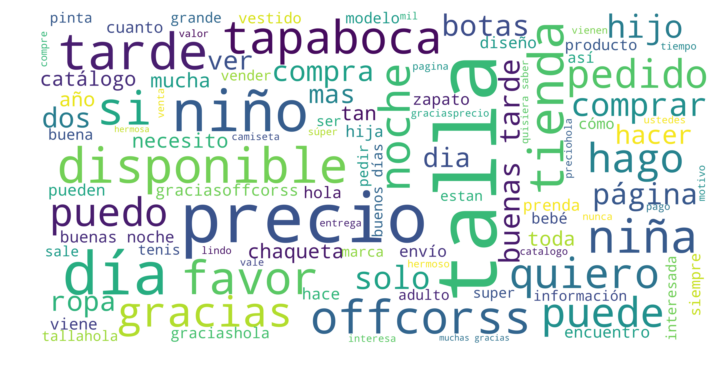

```python
# Wordcloud from the instagram responses text in the posts for OFFCORSS:

word_cloud_text = ''.join(ig_responses_offcorss_users.text_nsw)
wordcloud = WordCloud(max_font_size=100, max_words=100, background_color="white",\
#                       stopwords=stopwords.words(['spanish', 'english']),\
                          scale = 10,width=800, height=400).generate(word_cloud_text)
plt.figure(figsize=(12,7))
plt.imshow(wordcloud, interpolation="bilinear")
plt.axis("off")
plt.show()
```

Wordcloud from responses to EPK's Instagram posts from actual users:

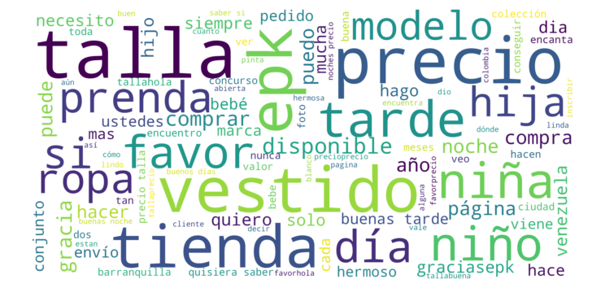

```python
# Wordcloud from the instagram responses text in the posts for EPK:

word_cloud_text = ''.join(ig_responses_epk_users.text_nsw)
wordcloud = WordCloud(max_font_size=100, max_words=100, background_color="white",\
#                       stopwords=stopwords.words(['spanish', 'english']),\
                          scale = 10,width=800, height=400).generate(word_cloud_text)
plt.figure(figsize=(12,7))
plt.imshow(wordcloud, interpolation="bilinear")
plt.axis("off")
plt.show()
```

Wordcloud from responses to POLITO's Instagram posts from actual users:

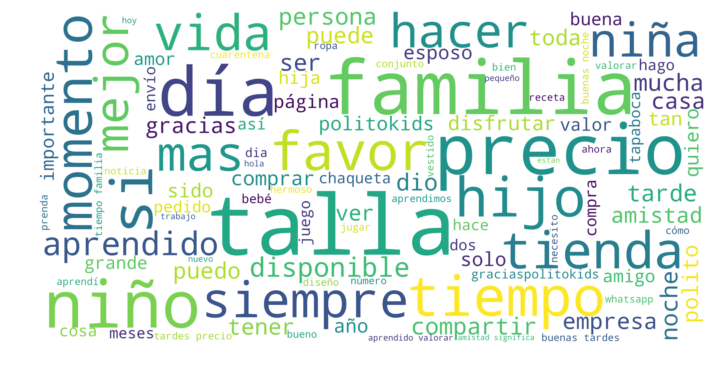

```python
# Wordcloud from the instagram responses text in the posts for POLITO:

word_cloud_text = ''.join(ig_responses_polito_users.text_nsw)
wordcloud = WordCloud(max_font_size=100, max_words=100, background_color="white",\
#                       stopwords=stopwords.words(['spanish', 'english']),\
                          scale = 10,width=800, height=400).generate(word_cloud_text)
plt.figure(figsize=(12,7))
plt.imshow(wordcloud, interpolation="bilinear")
plt.axis("off")
plt.show()
```

```python
from nltk.util import ngrams
from collections import Counter

# Defining function to get top n-grams:
def top_k_ngrams(word_tokens, n, k):
    n_gram_list = list(ngrams(word_tokens, n))
    n_gram_strings = [' '.join(each) for each in n_gram_list]
    n_gram_counter = Counter(n_gram_strings)
    most_common_k = n_gram_counter.most_common(k)
    print(most_common_k)
```

**Top unigrams from user responses on Instagram posts for each company:**

```python
top_k_ngrams(nltk.word_tokenize(' '.join(ig_responses_offcorss_users.text_nsw)), 1, 20)
```

```
[('precio', 1323), ('offcorss', 811), ('hola', 797), ('talla', 789), ('gracias', 612), ('buenas', 475), ('q', 360), ('favor', 349), ('quiero', 280), ('puedo', 229), ('tardes', 218), ('tapabocas', 196), ('tallas', 186), ('hago', 174), ('días', 172), ('niño', 172), ('buenos', 158), ('si', 157), ('niña…
```

```python
top_k_ngrams(nltk.word_tokenize(' '.join(ig_responses_epk_users.text_nsw)), 1, 20)
```

```
[('precio', 913), ('epk', 452), ('talla', 398), ('hola', 326), ('buenas', 240), ('gracias', 238), ('vestido', 225), ('favor', 213), ('q', 176), ('tienda', 119), ('hermoso', 115), ('tardes', 109), ('disponible', 107), ('si', 106), ('tallas', 93), ('niña', 85), ('quiero', 84), ('ropa', 82), ('encanta'…
```

```python
top_k_ngrams(nltk.word_tokenize(' '.join(ig_responses_polito_users.text_nsw)), 1, 20)
```

```
[('precio', 1119), ('talla', 576), ('hola', 515), ('politokids', 472), ('gracias', 463), ('familia', 440), ('buenas', 391), ('favor', 314), ('q', 296), ('aprendido', 270), ('amistad', 241), ('tiempo', 230), ('mejor', 187), ('amor', 181), ('hacer', 178), ('tardes', 178), ('puedo', 163), ('si', 162), …
```

- Based on wordclouds and unigrams analysis, it is seen that the words "precio" and "talla" are within the most used words in the responses, indicating the users' interest on the products' cost and sizes for each company.

**Top bigrams from user responses on Instagram posts for each company:**

```python
top_k_ngrams(nltk.word_tokenize(' '.join(ig_responses_offcorss_users.text_nsw)), 2, 20)
```

```
[('buenas tardes', 209), ('buenas noches', 144), ('precio favor', 131), ('precio precio', 125), ('buenos días', 120), ('gracias offcorss', 111), ('hola buenas', 99), ('q precio', 93), ('muchas gracias', 88), ('offcorss gracias', 78), ('precio hola', 77), ('talla precio', 74), ('hola precio', 64), ('…
```

```python
top_k_ngrams(nltk.word_tokenize(' '.join(ig_responses_epk_users.text_nsw)), 2, 20)
```

```
[('precio precio', 126), ('buenas tardes', 104), ('precio talla', 97), ('precio favor', 97), ('buenas noches', 65), ('talla precio', 64), ('precio vestido', 52), ('q precio', 49), ('hola buenas', 45), ('buenos días', 43), ('precio hola', 41), ('hola precio', 40), ('gracias epk', 39), ('favor precio'…
```

```python
top_k_ngrams(nltk.word_tokenize(' '.join(ig_responses_polito_users.text_nsw)), 2, 20)
```

```
[('buenas tardes', 169), ('precio precio', 145), ('precio favor', 131), ('buenas noches', 126), ('precio talla', 85), ('muchas gracias', 85), ('talla precio', 79), ('buenos días', 74), ('gracias politokids', 72), ('q precio', 71), ('hola buenas', 71), ('amistad significa', 67), ('amistad familia', 5…
```

- The bigrams provide similar information found before on unigrams finding that "precio talla" are within the most used words.

**Top trigrams from user responses on Instagram posts for each company:**

```python
top_k_ngrams(nltk.word_tokenize(' '.join(ig_responses_offcorss_users.text_nsw)), 3, 20)
```

```
[('hola buenas tardes', 54), ('hola buenas noches', 30), ('precio favor precio', 30), ('buenas tardes precio', 29), ('offcorss gracias offcorss', 29), ('hola buenos días', 24), ('offcorss muchas gracias', 20), ('gracias offcorss gracias', 20), ('buenas noches precio', 19), ('muchas gracias offcorss'…
```

```python
top_k_ngrams(nltk.word_tokenize(' '.join(ig_responses_epk_users.text_nsw)), 3, 20)
```

```
[('hola buenas tardes', 22), ('precio talla precio', 22), ('precio precio precio', 21), ('precio precio favor', 20), ('precio precio talla', 19), ('buenas tardes precio', 18), ('epk gracias epk', 17), ('buenas noches precio', 14), ('precio favor precio', 13), ('talla precio precio', 12), ('hola buen…
```

```python
top_k_ngrams(nltk.word_tokenize(' '.join(ig_responses_polito_users.text_nsw)), 3, 20)
```

```
[('buenas tardes precio', 37), ('hola buenas tardes', 35), ('b b b', 35), ('precio precio precio', 25), ('precio favor precio', 24), ('buenas noches precio', 23), ('hola buenas noches', 22), ('muchas gracias politokids', 22), ('politokids muchas gracias', 21), ('amistad significa poder', 20), ('sign…
```

- Trigrams do not provide more additional information than the found on unigrams and bigrams.

**Top users commenting on Instagram posts for each company:**

- The following analysis is made to identify the key users responding to the Instagram posts for each company:

```python
ig_responses_offcorss['username'].value_counts().head(11)
```

```
offcorss             6505
lyris_free             40
linamac3               40
andrewgfallon          36
juanito_palacio        36
danielaarroyave93      32
juanhxc                27
eliarcila              26
elisavillarrealr       25
laurishdzg             24
ethanthemodel          23
Name: username, dtype: int64
```

```python
ig_responses_epk['username'].value_counts().head(11)
```

```
epk                     2658
dianajanna                32
mpsamper                  26
tabathajanna              17
mundotoysco               16
mariatsamper              15
daleahumada               15
zafirasolano06            12
keny_rous                 12
itscamiyevara             12
isabelamazorra_model      11
Name: username, dtype: int64
```

```python
ig_responses_polito['username'].value_counts().head(11)
```

```
politokids              3622
isabelamazorra_model      55
alejazabala               53
model_juanitarc           40
nataliazabala             29
karenjul30                27
lahijadelsinu             27
gloriaherrera2011         25
heybran_whit_1119         24
casasdejuguetes           24
urriolayolany             23
Name: username, dtype: int64
```

**Users commenting on OFFCORSS' and EPK's Instagram posts:**

```python
users_offcorss_epk = []
for user in list(ig_responses_offcorss_users['username'].unique()):
    if user in list(ig_responses_epk_users['username'].unique()):
        users_offcorss_epk.append(user)
users_offcorss_epk
```

```
['12_felizcorazon',
 'manuelagonzales91',
 'luzadriana.francovalencia',
 'fashion_store_lm',
 'k_rolina_79',
 'melisav0210',
 'julybayona',
 'caroyja',
 'quintero.angiie',
 'vanessaecheverryescobar',
 'emi.help',
 'lauramariausmabetancur',
 'lauramari8802',
 'kyovacp',
 'tienda_stock_collection',
 'marsehernandes',
 'lachiquiari',
 'lilitorres38',
 '_saya140',
 'ligia20prado',
 'jenny.a_diaz',
 'consuelo_paternina',
 'marianaosaa',
 'helena_sampayo06',
 'jenni.duque.39',
 'bandi490',
 'ludyycabrera',
 'mariangelmazob',
 'dionebetancourthmarin',
 'losapuntesdegoyis',
 'diverplazacc',
 'geral62',
 'andrea.gallego.1990',
 'monis7412',
 'samylogi',
 'amurakids',
 'meilyjohanna',
 'caro2co',
 'corralesines7',
 'bigotonestienda',
```

[output cut: 125 more lines]

```
 'mariaeugenialegu',
 'annsofiaparra',
 'ismaelinadelsocorro',
 'margoryrendon22',
 'amalfi_arboleda',
 'juanjo040719',
 'marianita5630',
 'babyandtoddler',
 'amatista_tienda.esoterica',
 'lucianaacosta30',
 'angieumb_',
 'jennifer_perez56',
 'saeroto',
 'juanmac__',
 'veronikahenao29']
```

**Users commenting on OFFCORSS' and POLITO's Instagram posts:**

```python
users_offcorss_polito = []
for user in list(ig_responses_offcorss_users['username'].unique()):
    if user in list(ig_responses_polito_users['username'].unique()):
        users_offcorss_polito.append(user)
users_offcorss_polito
```

```
['luzadriana7707',
 'evygomezvargas',
 'manuamesa',
 'mafernandaduarte',
 'yojanna_correa',
 'k_rolina_79',
 'alexacostac23',
 'luzanrojas0422',
 'skarlybeltran',
 'milenagilsara',
 'isavasquez82',
 'clinicaviena_',
 'jhoanna.andrea1',
 'mendezf16joha1608',
 'vanessaecheverryescobar',
 'lauramari8802',
 'sandrav_salazar',
 'lupitaihl',
 'tienda_stock_collection',
 'natygiraldo22',
 'lorenasernamunera',
 '0130milena',
 'angieb_f',
 'dalispatriciavelezhernandez',
 'jesica.rivera.73',
 'caroliina0615',
 'luciacvillamizar',
 'mariangelmazob',
 'yanibyscarrillo',
 'sonia.j.aldana',
 'isacutevillegas',
 'irenimd',
 'gloriacecilia6729',
 'diioniixx_24',
 'mgalvis8',
 'kalema2008',
 'brandon_holguin2',
 'ladysmartinezgonz',
 'diequi1784',
 'catalinabetancurcruz',
```

[output cut: 209 more lines]

```
 'yulieth_isaza',
 'mariaisabelninovanegas',
 'sarohe_3',
 'mamamodoahorro',
 'sandramilena.vargasfalla1',
 'ktgomezr',
 'monicamantillamarin',
 'maryoe15',
 'sarahernandez.89',
 'shirley_gomez_',
 'yeidycorrea',
 'naeshka',
 'jeanny_massery',
 'tatiko_ruiz',
 'evelyn_24.12.16']
```

**Users commenting on Instagram posts from ALL the companies (OFFCORSS, EPK & POLITO):**

```python
users_all = []
for user in users_offcorss_epk:
    if user in users_offcorss_polito:
        users_all.append(user)
users_all
```

```
['k_rolina_79',
 'vanessaecheverryescobar',
 'lauramari8802',
 'tienda_stock_collection',
 'mariangelmazob',
 'caro2co',
 'corralesines7',
 'bigotonestienda',
 'elenithhb',
 'anlesgutyerre',
 'model_juanitarc',
 'eliza2205',
 'isabelamazorra_model',
 'narvaezedelmi',
 'marianaprin_es',
 'liiliipalaciio',
 'danibarco22',
 'claribelgiraldo',
 'chioflorez',
 'evasarahitorres',
 'pao.vas48',
 'ericka1echavez',
 'andrea_josealejo',
 'luisavega_130906',
 'leidyjihana',
 'mariaeugenialegu',
 'juanjo040719']
```

- The list above contains the users that make comments on Instagram posts for all the companies. It is found that these users are influencers, models or catalog sellers that work with all the companies. It would be interesting to see if some of these users make positive/negative comments on OFFCORSS posts and compare those responses on the other companies. Since most probably these users have significant number of followers on social networks (Instagram in this case).

**Average lenght of responses to Instagram posts for each company:**

```python
ig_responses_companies = [ig_responses_offcorss_users, ig_responses_epk_users, ig_responses_polito_users]
for company in ig_responses_companies:
    print(company['brand_username'].unique(), company['text_length'].mean())
```

```
['offcorss'] 6.80916116026
['epk'] 6.8984929078
['politokids'] 10.582346461
```

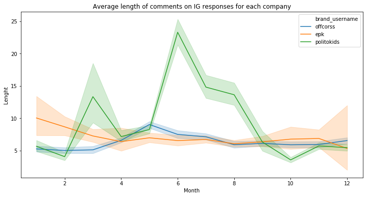

```python
fig = plt.figure(figsize=(12,6))
sns.lineplot(ig_responses['time'].dt.month, ig_responses['text_length'],
             hue='brand_username', data=ig_responses.loc[((ig_responses['username'] != 'offcorss') & (ig_responses['username'] != 'epk') & (ig_responses['username'] != 'politokids'))])
plt.title('Average length of comments on IG responses for each company')
plt.xlabel('Month')
plt.ylabel('Lenght')
plt.show()
```

- The plot above shows the average lenght of the responses to Instagram posts for each company grouped by month. OFFCORSS and EPK have similar responses' lengths along the year, while the responses to POLITO's posts tend to be longer especially along May-August (where the number of posts from this company increases as showed in the analysis above).

**Top10 hashtags used in responses to Instagram posts for each company:**

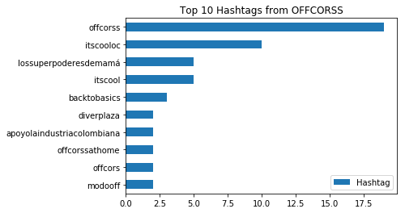

```python
get_top10_hashtags(ig_responses_offcorss_users, 'hashtags', 'brand_username')
```

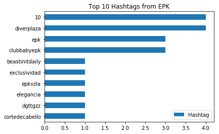

```python
get_top10_hashtags(ig_responses_epk_users, 'hashtags', 'brand_username')
```

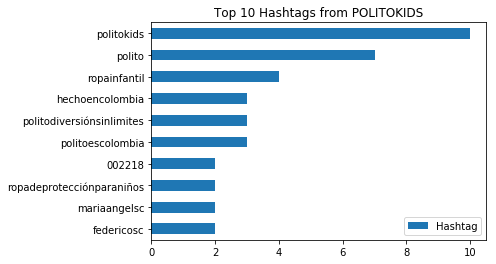

```python
get_top10_hashtags(ig_responses_polito_users, 'hashtags', 'brand_username')
```

- The hashtags used in the responses to the Instagram posts for each company are similar to those used in the original posts. For OFFCORSS it is seen again that there are mainly two hashtags used, while the other companies (EPK and POLITO) have more hashtags.